# Participation in cancer screening programmes in Colombian women of reproductive age - prevalence and determinants

Tamara Dörr

2024-03-31

# Introduction

## Background

Early cancer screening for women has been established worldwide for both, cervix cancer and breast cancer. While the first comprises yearly PAP smears with result-specific follow-up intervals for all women after menarche, breast cancer screening is recommended for all women of 50 years and older. In Colombia the participation in breast cancer screening has been reported to be low leading to cancer cases to be detected in advanced stages. However, less is known about the participation in cervix cancer programmes of also younger women and if there are differences to be noted in associated factors compared to participation in breast cancer screening.

## Objective

This study aims to investigate the participation in cancer screening programmes of women aged 15 to 49 years in Colombia. The original data for this analysis is the 2015/2016 Colombian Demographic and Health Surveys (DHS). More info about the survey can be found here.

### Detailed Objectives

1. Determine the overall percentage of women participating in the cervical cancer screening programme and describe age-dependent distribution.
2. Determine how many of those who have not participated in the screening are at risk for HPV infection.
3. Describe the reasons for not participating in the cancer screening programme depending on age and relationship status.
4. Compare the characteristics of women participating in the cervical cancer screening programme with those who do not and look at the following variables: Age, relationship status, education, wealth and number of children.

## Participation in Cervical Cancer Screening Programme in Colombia

### Overall participation

My first objective was to look at the overall participation in the cervical cancer screening programme in colombian women between 15-49. The women were asked if they had ever taken a cytology test which would be considered having participated in the programme. Since Colombia is a heterogenerous country, the first aim was to depict it per region of Colombia.

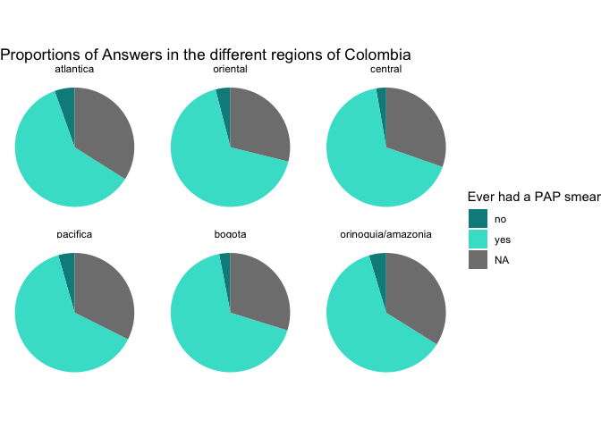

As we can see, the majority of women have had a cytology in their life, however for around a fourth this information is missing and a considerable proportion has never had a cytology. In the graph we see that there are no major differences between the different regions. However, participation may differ by age. Therefore I decided to look at participation by age group which can be seen below. The age groups have been defined by the DHS in 5-year-ranges.

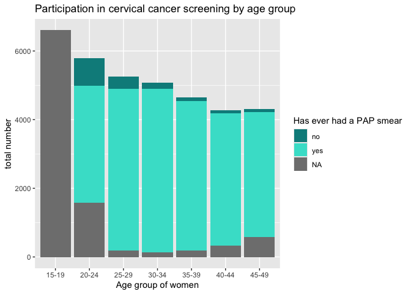

As we can see, women below the age of 20 have not answered the question on having being screened for cervical cancer. This may be due to the fact, that in Colombia the screening is recommended for women 25 and older. However, since we know that PAP smear sensitivity for a single test is very low and serial testing is needed to reach an adequate level of certainty, beginning early is recommended. Additionally, we know that sexual activity is a major risk factor for the acquision of HPV infection and thus, cervical cancer, I wanted to investigate, what proportion of these women are at risk for HPV infection and would therefore potentially benefit from the screening.

### Population at risk

#### Women between 15 and 19 years

In the following figure the proportions of sexually active women in the age group 15-19 are depicted.

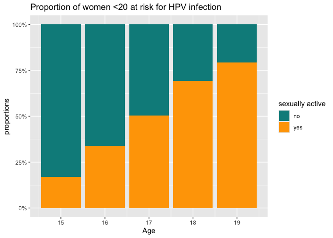

We can see that a considerable proportion of the women in this age group are or have been sexually active and are therefore considered to be at risk. The proportion increases with age and at the age of 19 more then 75% would be considered at risk of HPV infection and should therefore be screened.

#### Women aged 20 or older

To identify the women at risk that are 20 and older, we could see in the first plot that the majority has taken a test. Although it is possible that those who did not participate are not at risk, they could still be if they are or have been sexually active. I therefore wanted to look at the proportion at risk of those who did not take a test also in the other age groups. To avoid bias from missing values, those who did not answer the question on having had a cytology are not included in the following figure.

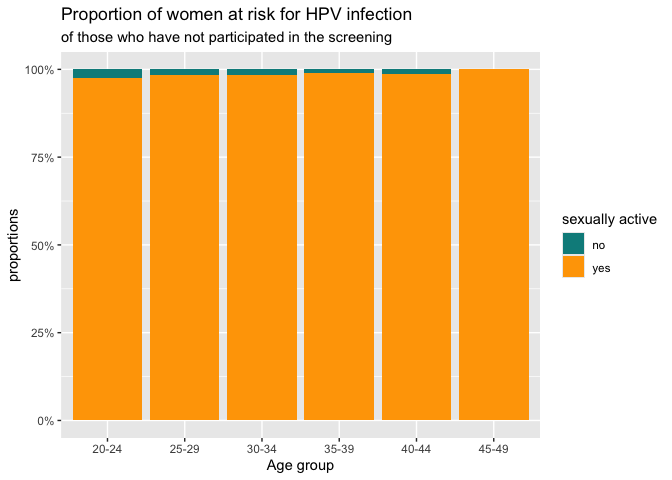

We can see that the majority of those who have not participated in the cervical cancer screening programme are or have been sexually active and should therefore be considered to be at risk.

### Reasons for non-participation

In the DHS Survey, the women who answered that they hadn’t had a cytology were consequently asked to give a reason for not participating in the cervical cancer screening. As these reasons might be different across age groups, this analysis was also done per age group.

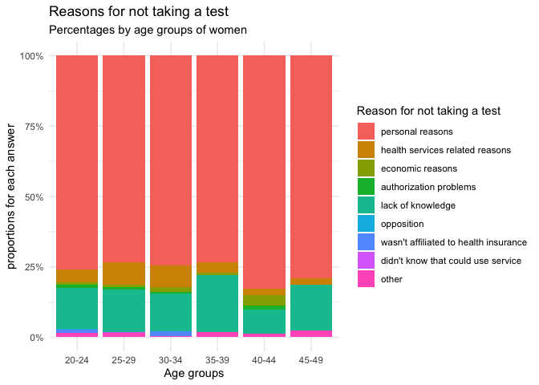

As we can see, personal reasons were most commonly stated as reason for deciding against a test. Another common reason was the lack of knowledge. Especially, since these personal reasons might be influenced by their relationships, relationship status could also influence the distribution of reasons.

I therefore decided to also look at the reasons by relationship status which is depicted in the next graph.

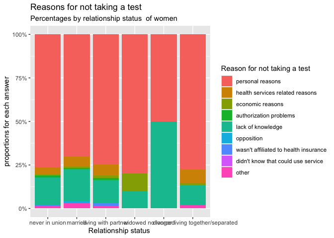

We can see that the lack of knowledge is highest in those who are divorced which is an interesting finding that should be studied further.

### Characteristics of women

My last objective was to look at some characteristics of the women who did participate in the screening compared to those who didn’t. In the following table we see an overview of the characteristics age, relationship status, highest level of education achieved, their wealth category and the number of children they have.

|  | no | yes | p |
| --- | --- | --- | --- |
| n | 1627 | 24720 |  |
| Age (mean (SD)) | 27.59 (7.35) | 34.38 (8.11) | <0.001 |
| Relationship status (%) |  |  | <0.001 |
| never in union | 664 (40.8) | 3205 (13.0) |  |
| married | 120 ( 7.4) | 5376 (21.7) |  |
| living with partner | 620 (38.1) | 11254 (45.5) |  |
| widowed | 10 ( 0.6) | 451 ( 1.8) |  |
| divorced | 2 ( 0.1) | 186 ( 0.8) |  |
| no longer living together/separated | 211 (13.0) | 4248 (17.2) |  |
| Highest education (%) |  |  | <0.001 |

[output cut: 11 more lines]

As we can see in the table there are differences in terms of the variables looked at.

The women that did not participate in the cervical cancer screening programme were younger, less likely to are or ever have been in a relationship and have fewer children. The p-values are given but should be interpreted with caution since the large sample size may distort the relevance of the differences observed. For example in terms of wealth and education the percentages do not differ greatly and statistical significance which has been calculated using Chi-squared test, is likely due to sample size.